# Regressions in R

Alexander Cardazzi

July, 2021

# Setting Up R for Use

When you open up a blank RScript, there are a few things you may want to put at the very top of your code. I like to lead with any libraries I will need. While there are a lot of things you can do with base R, people write packages to make our lives easier. For example, here is a list of a few packages I use in almost all of my scripts:

- `lubridate`: this package is for working with date objects. Dates are not always easy to work with but I cannot recommend this package enough. [Cheatsheet](https://rawgit.com/rstudio/cheatsheets/master/lubridate.pdf).
- `stargazer`: this package makes regression output beautiful and simple. [Cheatsheet](https://www.jakeruss.com/cheatsheets/stargazer/).
- `data.table`: this is for reading in large CSVs.[^1]
- `scales`: this is for changing the opacity of plot colors. Purely aesthetic, but I love it.
- `fixest`: this package is excellent for when you have many fixed effects and/or observations. There is too much to cover on this, but see [here](https://cran.r-project.org/web/packages/fixest/vignettes/fixest_walkthrough.html) for more details.
- `modelsummary`, `kableExtra`: unfortunately, `fixest` does not work for stargazer, so you will need to use these. [Here](https://alexcardazzi.github.io/using-r/2021/modelsummary_example.html) is a code snippet (by me) you might be interested in using. [Here](https://vincentarelbundock.github.io/modelsummary/articles/modelsummary.html) is the package's vignette.

Note that before you load a library (`library("scales")`), you need to install the library (`install.packages("scales")`). Installing packages only has to be done the very first time you use a package, then it will be on your machine forever.

Next, try to always set up a working directory. Suppose you have a folder for your project, and lets say that file path is: `C:/Users/alexc/Desktop/sharkAttacks`. Within this folder, I might have subfolders like raw_data, cleaned_data, literature, code, etc. It is likely that I'll want to save my script in the code folder but read/write data to the raw_data/cleaned_data folders. To make this simple, I can do this:

```r
setwd("C:/Users/alexc/Desktop/sharkAttacks/")
#read in data

# do stuff ...

setwd("../cleaned_data")
#write out data
```

The last thing is to read in the datasets you need. Often times, you need to read in more than one dataset, merge them, etc. Let's read in both [`knicks.csv`](https://alexcardazzi.github.io/using-r/empirical-workshop/data/knicks.csv) dataset and [`knicks_stats.csv`](https://alexcardazzi.github.io/using-r/empirical-workshop/data/knicks_stats.csv). As you have seen before, `knicks` is simply the roster, but the `knicks_stats.csv` is new. This file contains data on season totals for each player.

```r
#library("enter library here")

setwd("C:/Users/alexc/Desktop/Empirical Workshop 2021/data")
rm(list = ls()) #this clears my workspace ... be careful with this

roster <- read.csv("knicks.csv", stringsAsFactors = F)
stats <- read.csv("knicks_stats.csv", stringsAsFactors = F)
```

## Important Functions

You can check out the data by clicking on the object in the Enviornment tab, or typing `View(roster)` into the console. Before we get too much farther, we need to explore the data. Here is a list of some invaluable functions. Mastering these few functions take you from level 1 to level 2, and can save you hours of time.

- `table()`
- `aggregate()`
- `match()`

First, in the `roster` data frame, we might want to see the distribution of player experience. We can easily do this by calling:

```r
table(roster$Exp)
```

```
##
##  1 10  2  3  4  5  7  9  R
##  6  2  2  2  1  3  2  1  4
```

Notice the odd sorting in this table. This is due to the rookies being given an "R". Let's change this and remake the table.

```r
roster$Exp[roster$Exp == "R"] <- 0
roster$Exp <- as.numeric(roster$Exp)
table(roster$Exp)
```

```
##
##  0  1  2  3  4  5  7  9 10
##  4  6  2  2  1  3  2  1  2
```

It can also be helpful to plot these for visualization purposes. You can simply use `plot(table(roster$Exp))`. Now, what if we wanted to look at the distribution of experience by position? We can add in a second vector to table.

```r
table(roster$Exp, roster$Pos)
```

```
##
##      C PF PG SF SG
##   0  1  1  0  0  2
##   1  0  2  2  0  2
##   2  0  1  0  0  1
##   3  0  0  1  1  0
##   4  0  1  0  0  0
##   5  0  0  1  0  2
##   7  1  1  0  0  0
##   9  0  0  0  0  1
##   10 1  0  0  0  1
```

Table is especially helpful when you are counting events per some unit. For example, suppose you have a dataset where every entry is a crime with a date as a timestamp. Well, you can use `table(crime$date)` and this will generate the number of crimes per day. You might need to be careful, though, since if there is a day missing altogether, R will not know this!

What if we are not interested in counts but rather averages, or some other function? This is where `aggregate()` comes in. This function takes 3 arguements. First, the vector(s) you to aggregate. Second, the vectors you want to collapse to, and finally the function. For example, suppose we want to know the average weight by position.

```r
agg1 <- aggregate(roster$Wt, by = list(roster$Pos), FUN = mean)
agg1
```

```
##   Group.1   x
## 1       C 250
## 2      PF 237
## 3      PG 190
## 4      SF 201
## 5      SG 210
```

Notice the column names of dataframe. Terrible. Instead, we can name them like: `aggregate(Wt = roster$Wt, by = list(Pos = roster$Pos), FUN = mean)`

What if, instead, we are interested in average height and weight by position? Let's remember how dataframes are special cases of named lists.

```r
agg2 <- aggregate(list(Wt = roster$Wt, Ht_inches = roster$Ht_inches), by = list(Pos = roster$Pos), FUN = mean)
agg2
```

```
##   Pos  Wt Ht_inches
## 1   C 250  83.33333
## 2  PF 237  81.66667
## 3  PG 190  74.50000
## 4  SF 201  80.00000
## 5  SG 210  76.22222
```

```r
agg3 <- aggregate(roster[,c("Wt", "Ht_inches")], by = list(Pos = roster$Pos), FUN = mean)
agg3
```

```
##   Pos  Wt Ht_inches
## 1   C 250  83.33333
## 2  PF 237  81.66667
## 3  PG 190  74.50000
## 4  SF 201  80.00000
## 5  SG 210  76.22222
```

What if we wanted average weight by position and country? This is also easy, but we need to be careful to remember that there is not every single position-county combo in the data. For example, there is a PG-be combo, but there is no C-be combo. If we want to keep the non-existent combos, we need to use `drop = FALSE`. `table()` will count the zero combinations, but `aggregate` cannot take a mean of something that does not exist. Therefore, it assumes that you don't want that observation and R drops it.

```r
agg4 <- aggregate(roster$Wt, by = list(Pos = roster$Pos, roster$X), FUN = mean)
agg4
```

```
##   Pos Group.2   x
## 1  PG      be 190
## 2  PG      cd 200
## 3   C      ch 262
## 4  SF      hr 201
## 5   C      us 244
## 6  PF      us 237
## 7  PG      us 185
## 8  SG      us 210
```

```r
agg5 <- aggregate(roster$Wt, by = list(Pos = roster$Pos, roster$X), FUN = mean, drop = FALSE)
agg5
```

```
##    Pos Group.2   x
## 1    C      be  NA
## 2   PF      be  NA
## 3   PG      be 190
## 4   SF      be  NA
## 5   SG      be  NA
## 6    C      cd  NA
## 7   PF      cd  NA
## 8   PG      cd 200
## 9   SF      cd  NA
## 10  SG      cd  NA
## 11   C      ch 262
## 12  PF      ch  NA
## 13  PG      ch  NA
## 14  SF      ch  NA
## 15  SG      ch  NA
## 16   C      hr  NA
## 17  PF      hr  NA
## 18  PG      hr  NA
## 19  SF      hr 201
## 20  SG      hr  NA
## 21   C      us 244
## 22  PF      us 237
## 23  PG      us 185
## 24  SF      us  NA
## 25  SG      us 210
```

As a final note about `aggregate()`, you can use any function with it! Instead of `mean`, you can use `sd`, `sum`, or anything.

Okay, now you're probably thinking: why did I load in the second dataset??? Well, we want to merge/join these two datasets! You are going to google merging in R at some point in your life and I am here to tell you: all you need is the `match()` function. That's it! Don't use merge, join, or anything else. Before I even pull anything from the `stats` dataframe, I need to know the corresponding order of `roster` within `stats`.

```r
m <- match(roster$Player, stats$Var.2)
m
```

```
##  [1] 16 20 13  2 18 21 NA  8 23 17 15  9  1 11 19 22  4 10  7 NA 12  6  3
```

What does this tell us? It tells us that `Kadeem Allen` is the `16`th row in the `stats` dataframe. So now, we can use `m` to reorder the `stats` dataset how we need it to merge. You might also notice that there are NA values in `m`. This is what happens where there is no match. This is due to quirks in how the names are typed which we will ignore for now, but it's important to know. Now, if we want to know how many games each player appeared in, we use the following:

```r
roster$G <- stats$G[m]
```

If we want to match in many columns:

```r
roster[,c("G", "GS", "PTS")] <- stats[m,c("G", "GS", "PTS")]
```

Before moving on, I want to mention something people often get stuck on. Hopefully you see how to match based on one variable, but what about two? Or three? We will talk about strings later, but suppose you want to match by both city and year. You would do something like: `match(paste(abc$city, abc$year), paste(xyz$city, xyz$year))`.

These are some really important things in R. I would encourage you to go over this a few times and really understand what is going on. The power of these three functions cannot be overstated.

# Econometrics

Let's talk about regressions and econometrics. Let's use a dataset native to R called `quakes`. This contains a bunch of earthquake readings in Fiji. Documentation [here](https://stat.ethz.ch/R-manual/R-devel/library/datasets/html/quakes.html). To read it in, use:

```r
data("quakes")
str(quakes)
```

```
## 'data.frame':    1000 obs. of  5 variables:
##  $ lat     : num  -20.4 -20.6 -26 -18 -20.4 ...
##  $ long    : num  182 181 184 182 182 ...
##  $ depth   : int  562 650 42 626 649 195 82 194 211 622 ...
##  $ mag     : num  4.8 4.2 5.4 4.1 4 4 4.8 4.4 4.7 4.3 ...
##  $ stations: int  41 15 43 19 11 12 43 15 35 19 ...
```

`str()` gives the structure of the object. There are 1000 rows and 5 variables.

The first thing you'll want to show is summary stats. There are two ways (that I use) to show summary stats. The first one uses a library called `stargazer` and the second uses both `modelsummary` and `kableExtra`. Stargazer is much easier, but modelsummary is way more customizable. I will only focus on `stargazer` here:

```r
library("stargazer")
stargazer(quakes, type = "text", #make this "latex" if you want that output
          summary.stat = c("n", "mean", "sd"))
```

```
##
## ================================
## Statistic   N    Mean   St. Dev.
## --------------------------------
## lat       1,000 -20.643  5.029
## long      1,000 179.462  6.069
## depth     1,000 311.371 215.535
## mag       1,000  4.620   0.403
## stations  1,000 33.418   21.900
## --------------------------------
```

The variable "stations" tells the number of stations that reported the earthquake. It would be interesting to see if depth or magnitude impacted this. Obviously, one of the first steps would be to plot or to run correlations. Let's try magnitude and stations.

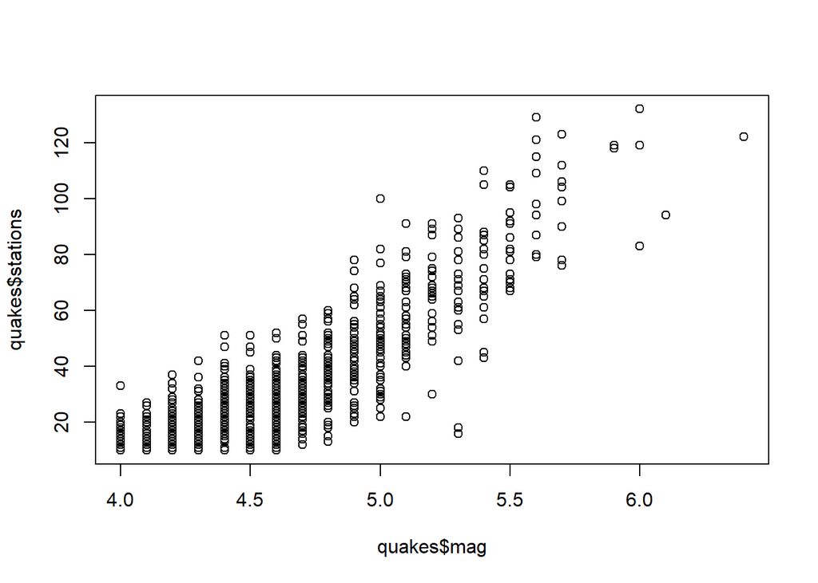

```r
plot(quakes$mag, quakes$stations)
```

```r
cor.test(quakes$mag, quakes$stations)
```

```
##
##  Pearson's product-moment correlation
##
## data:  quakes$mag and quakes$stations
## t = 51.231, df = 998, p-value < 2.2e-16
## alternative hypothesis: true correlation is not equal to 0
## 95 percent confidence interval:
##  0.8331527 0.8674048
## sample estimates:
##       cor
## 0.8511824
```

We will do much more with plotting later, but for now, we can see a relationship. To run a univariate regression:

```r
reg1 <- lm(stations ~ mag, data = quakes)
```

Pretty simple! To check out the diagnostics:

```r
summary(reg1)
```

```
##
## Call:
## lm(formula = stations ~ mag, data = quakes)
##
## Residuals:
##     Min      1Q  Median      3Q     Max
## -48.871  -7.102  -0.474   6.783  50.244
##
## Coefficients:
##              Estimate Std. Error t value Pr(>|t|)
## (Intercept) -180.4243     4.1899  -43.06   <2e-16 ***
## mag           46.2822     0.9034   51.23   <2e-16 ***
## ---
## Signif. codes:  0 '***' 0.001 '**' 0.01 '*' 0.05 '.' 0.1 ' ' 1
##
## Residual standard error: 11.5 on 998 degrees of freedom
## Multiple R-squared:  0.7245, Adjusted R-squared:  0.7242
## F-statistic:  2625 on 1 and 998 DF,  p-value: < 2.2e-16
```

To add in multiple variables:

```r
reg2 <- lm(stations ~ mag + depth, data = quakes)
summary(reg2)
```

```
##
## Call:
## lm(formula = stations ~ mag + depth, data = quakes)
##
## Residuals:
##     Min      1Q  Median      3Q     Max
## -46.506  -6.996  -0.453   6.643  47.259
##
## Coefficients:
##               Estimate Std. Error t value Pr(>|t|)
## (Intercept) -1.920e+02  4.332e+00 -44.335  < 2e-16 ***
## mag          4.791e+01  9.016e-01  53.135  < 2e-16 ***
## depth        1.318e-02  1.685e-03   7.822 1.32e-14 ***
## ---
## Signif. codes:  0 '***' 0.001 '**' 0.01 '*' 0.05 '.' 0.1 ' ' 1
##
## Residual standard error: 11.17 on 997 degrees of freedom
## Multiple R-squared:  0.7404, Adjusted R-squared:  0.7399
## F-statistic:  1422 on 2 and 997 DF,  p-value: < 2.2e-16
```

Now, if you want to see all the models together, you can use `stargazer` once again.

```r
stargazer(reg1, reg2,
          type = "text")
```

```
##
## =========================================================================
##                                      Dependent variable:
##                     -----------------------------------------------------
##                                           stations
##                                (1)                        (2)
## -------------------------------------------------------------------------
## mag                         46.282***                  47.909***
##                              (0.903)                    (0.902)
##
## depth                                                   0.013***
##                                                         (0.002)
##
## Constant                   -180.424***                -192.043***
##                              (4.190)                    (4.332)
##
## -------------------------------------------------------------------------
## Observations                  1,000                      1,000
## R2                            0.725                      0.740
## Adjusted R2                   0.724                      0.740
## Residual Std. Error     11.501 (df = 998)          11.169 (df = 997)
## F Statistic         2,624.656*** (df = 1; 998) 1,422.047*** (df = 2; 997)
## =========================================================================
## Note:                                         *p<0.1; **p<0.05; ***p<0.01
```

Of course, we can also use logistic regression to model a binary outcome or a poisson to model a count. For this, we use `glm()`.

```r
# making a binary variable:
quakes$stations_30plus <- quakes$stations >= 30
reg3 <- glm(stations_30plus ~ mag + depth, data = quakes, family = "binomial")
reg4 <- glm(stations ~ mag + depth, data = quakes, family = "poisson")
stargazer(reg1, reg2, reg3, reg4,
          type = "text",
          omit.stat = c("f", "ser"))
```

```
##
## ====================================================================
##                                  Dependent variable:
##                   --------------------------------------------------
##                          stations         stations_30plus  stations
##                             OLS              logistic      Poisson
##                       (1)         (2)           (3)          (4)
## --------------------------------------------------------------------
## mag                46.282***   47.909***     7.315***      1.189***
##                     (0.903)     (0.902)       (0.472)      (0.012)
##
## depth                          0.013***      0.002***     0.0003***
##                                 (0.002)      (0.0004)     (0.00003)
##
## Constant          -180.424*** -192.043***   -34.563***    -2.205***
##                     (4.190)     (4.332)       (2.227)      (0.059)
##
## --------------------------------------------------------------------
## Observations         1,000       1,000         1,000        1,000
## R2                   0.725       0.740
## Adjusted R2          0.724       0.740
## Log Likelihood                               -366.572     -4,023.375
## Akaike Inf. Crit.                             739.143     8,052.749
## ====================================================================
## Note:                                    *p<0.1; **p<0.05; ***p<0.01
```

Next, within regressions, there are shortcuts for interactions and other manipulations. There are three you should know: `*`, `:`, and `I()`. If you want a full set of interactions (A + B + AxB), use `*` between two variables. If you want just the interaction term, use `:`. Finally, if you want to do calculations within the regression, you can do `I(x * 100)`, `I(x^2)`, etc.

## `fixest`

Extremely large datasets usually require alternate solutions. Since R is open source, very kind individuals have written highly optimized packages for us to use. `fixest` is one of these packages. The way to write formulas for `fixest` is very similar to how you would write them for `lm()`. Below is an example:

```r
reg_x <- feols(y1 ~ x1 + x2 | FE1 + FE2, data = df)
```

- `y` is an outcome variable. This can be changed to `list(y1, y2)` if you have more than one outcome variable.
- `x1`, `x2` are independent variables. If you want to run multiple models, you can do `sw(x1, x2, x1 + x2)`. This will do one model with `x1`, one with `x2` and one with both. `sw0()` will do all three plus one without any of them.
- `x1`, `x2` are fixed effects. By default, standard errors are clustered by `FE1`, but you can change this in post.
[^1]: look into readRDS and saveRDS. Essentially, this saves an R object to your file directory. This provides two benefits over a CSV: it is zipped so much smaller and R can read the data in way quicker than a CSV. Drawback is you cannot open with Excel or Notepad. Should be used for LARGE datasets.